# Lab 3

Ryan Pate

3/3/2021

Use `ggplot2` to create the plots, and `dplyr` to manipulate the data frame as much as possible. You may want to rename the columns of the data frame for your convenience using rename in dplyr.

1. Find the average years of education for the respondents with each marital status. Arrange your output in a meaningful order and print. Describe any patterns you find.

   ```r
   dat <- readxl::read_xls('/Users/ryanpate/Downloads/GSS.xls')
   dat <- rename(dat, married = "Marital status")
   dat <- rename(dat, ID = "Respondent id number")
   dat <- rename(dat, year = "Gss year for this respondent")
   dat <- rename(dat, schooling = "Highest year of school completed")
   dat <- rename(dat, sex = "Respondents sex")
   dat <- rename(dat, party = "Political party affiliation")
   dat <- rename(dat, happy = "General happiness")
   dat <- rename(dat, ballot = "Ballot used for interview")

   filtered <- dat[!(dat$schooling=="Don't know" | dat$schooling=="No answer" | dat$married=="No answer" | dat$party=="No answer"),]
   filtered$schooling <- as.numeric(as.character(filtered$schooling))
   edu <- filtered %>%
     group_by(married) %>%
     summarize(Mean_schooling = mean(schooling, na.rm=TRUE)) %>%
     arrange(desc(Mean_schooling))
   edu
   ```

   ```
   ## # A tibble: 6 x 2
   ##   married       Mean_schooling
   ##   <chr>                  <dbl>
   ## 1 Never married           13.4
   ## 2 Divorced                13.1
   ## 3 Married                 13.0
   ## 4 Separated               11.9
   ## 5 Widowed                 11.2
   ## 6 <NA>                   NaN
   ```

2. Create a single data frame containing records for the better educated respondents with each marital status. A “better educated” respondent is someone who has strictly more years of education than the average among those with the same marital status. Print the structure of the data frame.

   ```r
   highedu <- subset(filtered, filtered$schooling > 12 & filtered$married == "Married" | filtered$schooling > 13 & filtered$married == "Divorced" | filtered$schooling > 13 & filtered$married == "Never married"
                 | filtered$schooling > 11 & filtered$married == "Widowed" | filtered$schooling > 11 & filtered$married == "Separated" | filtered$schooling > 15 & filtered$married == "No answer")

   str(highedu)
   ```

   ```
   ## tibble [30,550 × 8] (S3: tbl_df/tbl/data.frame)
   ##  $ year     : num [1:30550] 1972 1972 1972 1972 1972 ...
   ##  $ ID       : num [1:30550] 1 4 6 8 11 16 17 19 20 23 ...
   ##  $ married  : chr [1:30550] "Never married" "Married" "Never married" "Never married" ...
   ##  $ schooling: num [1:30550] 16 17 14 16 13 14 14 17 14 13 ...
   ##  $ sex      : chr [1:30550] "Female" "Female" "Male" "Male" ...
   ##  $ party    : chr [1:30550] "Ind,near dem" "Not str democrat" "Ind,near dem" "Ind,near dem" ...
   ##  $ happy    : chr [1:30550] "Not too happy" "Not too happy" "Pretty happy" "Not too happy" ...
   ##  $ ballot   : chr [1:30550] "Not applicable" "Not applicable" "Not applicable" "Not applicable" ...
   ```

For each of the investigation below, create at least one numerical summary and one appropriate visualization. Write a paragraph to describe your findings and the variables you used.

3. How is the happiness of a respondent related to his/her marriage status? Define that a person is happy if the response to question is “Very happy” or “Pretty happy”.

   ```r
   happy <- subset(filtered, filtered$happy == "Very happy" | filtered$happy == "Pretty happy")
   happymarry <- happy %>% count(married, happy, sort=TRUE)
   happymarry
   ```

   ```
   ## # A tibble: 10 x 3
   ##    married       happy            n
   ##    <chr>         <chr>        <int>
   ##  1 Married       Pretty happy 16388
   ##  2 Married       Very happy   12760
   ##  3 Never married Pretty happy  7899
   ##  4 Divorced      Pretty happy  4648
   ##  5 Widowed       Pretty happy  3230
   ##  6 Never married Very happy    2708
   ##  7 Divorced      Very happy    1481
   ##  8 Widowed       Very happy    1386
   ##  9 Separated     Pretty happy  1138
   ## 10 Separated     Very happy     335
   ```

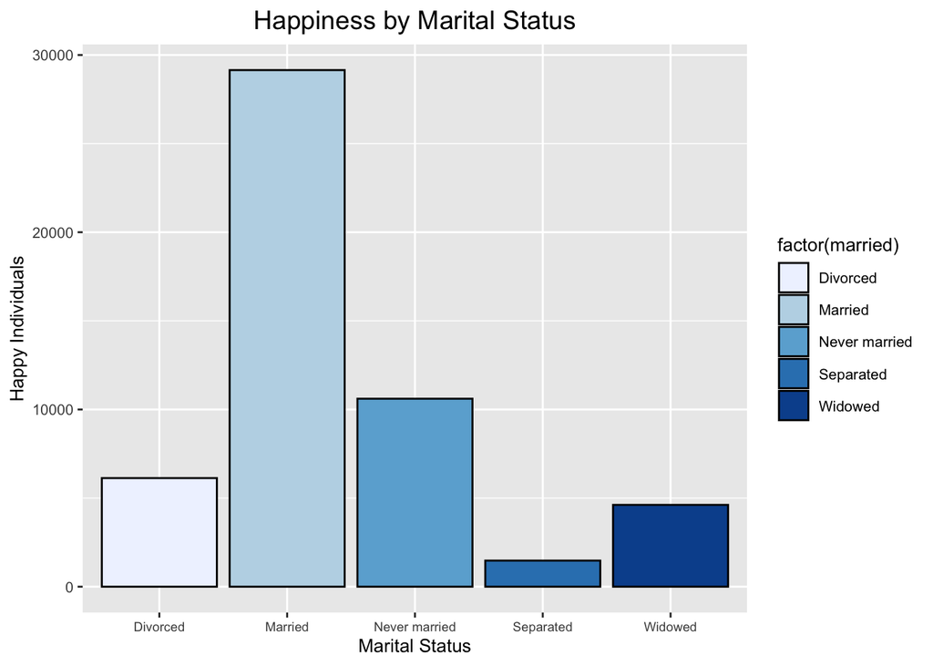

   ```r
   happiness <- happy %>% count(married, happy="Happiness", sort=TRUE)
   ggplot(happiness, aes(married, n, fill=factor(married))) + geom_col(color="black") + theme(text = element_text(size=10), axis.text.x = element_text(angle=0, hjust=0.5, size=7)) + labs(title="Happiness by Marital Status", x="Marital Status", y="Happy Individuals") +
     theme(plot.title = element_text(size=14, hjust=0.5)) + scale_fill_brewer(palette="Blues")
   ```

4. Does party affiliation affect the relationship you found in the last question?

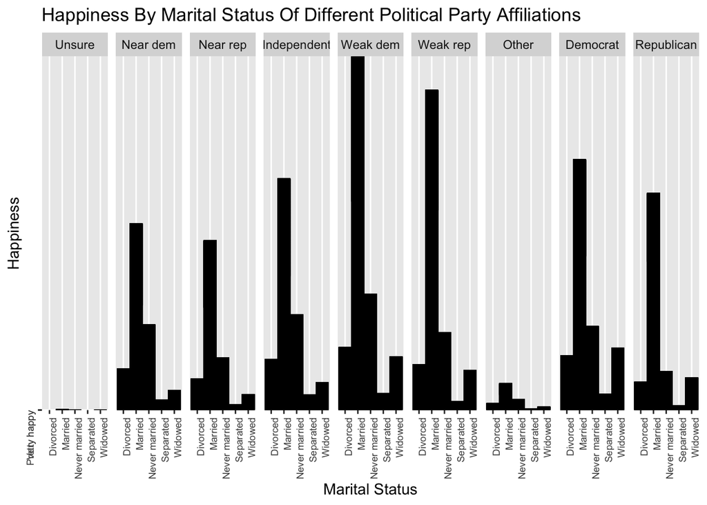

   ```r
   partylabs <- c("Unsure", "Near dem", "Near rep", "Independent", "Weak dem", "Weak rep", "Other", "Democrat", "Republican")
   names(partylabs) <- c("Don't know", "Ind,near dem", "Ind,near rep", "Independent", "Not str democrat", "Not str republican", "Other party", "Strong democrat", "Strong republican")


   ggplot(happy, aes(married, happy), fill=factor(married)) + geom_col(color="black") + facet_grid(. ~ party, labeller = labeller(party = partylabs)) +
     theme(axis.text = element_text(angle=90, hjust=1, size=7)) + labs(title="Happiness By Marital Status Of Different Political Party Affiliations", x="Marital Status", y="Happiness")
   ```

5. How is marital status related to the education of a respondent? What are possible reasons accounting for the patterns you see?

[figure not shown]

   ```r
   ggplot(dat, aes(married, schooling)) + geom_col()
   ```

6. Explore two more interesting questions, and answer those questions using the GSS data.

   The relationship between year and level of schooling.

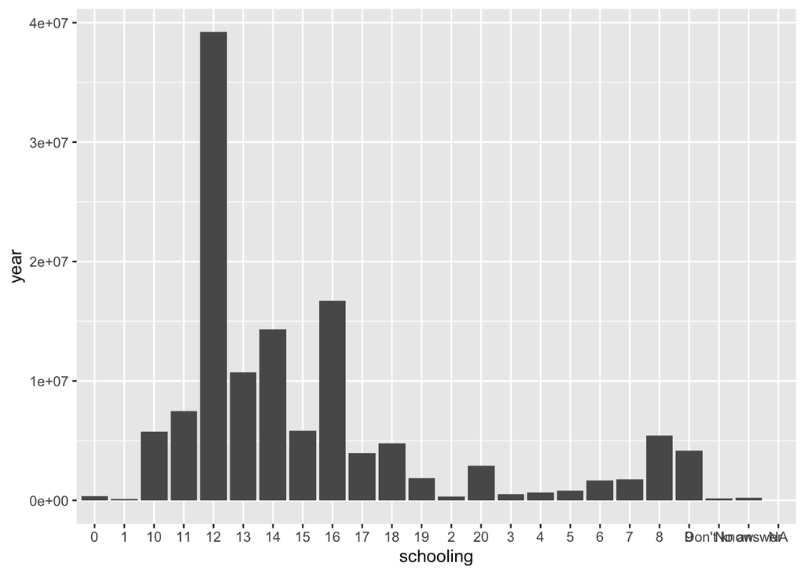

   ```r
   ggplot(dat, aes(schooling, year)) + geom_col()
   ```

The team’s exploration will be evaluated according to the general interest and the depth of the exploration.